# Practice 9

## Question 1

### a)

Download the latest US State-level COVID-19 dataset from the New York Times data portal from https://raw.githubusercontent.com/nytimes/covid-19-data/master/us-states.csv. You should be able to use `read_csv()` to immediately download this data as long as you are connected to the internet.

```r
covid_raw <- read_csv("https://raw.githubusercontent.com/nytimes/covid-19-data/master/us-states.csv")
```

### b)

Calculate and report in a sentence the mean number of new COVID deaths reported in New York from January 1st, 2022 to now. In order to do this:

1. First filter the COVID State dataset to contain only information from New York
2. Next, arrange the observations according to date.
3. Create a new variable called `new_deaths` by using `mutate(new_deaths = deaths - lag(deaths))`. The `lag()` function will look backward one observation to obtain cases from the previous day.
4. Filter the data frame to only include dates from 01/01/22 onwards. This column should be in date format, so using >= logic will work.

```r
ny_covid21 <- covid_raw %>%
  filter(state == "New York") %>%
  arrange(date) %>%
  mutate(new_deaths = deaths - lag(deaths)) %>%
  filter(date >= "2022-01-01")

mean_nd <- ny_covid21 %>%
  pull(new_deaths) %>%
  mean()
```

### c)

Compute and report the 95% confidence interval of the mean number of new deaths reported (using the standard formula for SE) in New York over from 01/01/22 onward.

```r
standard_ci <- ny_covid21 %>%
  summarize(mean_nd = mean(new_deaths),
            total_n = n(),
            se = sd(new_deaths)/sqrt(total_n),
            lower_ci = mean_nd - 1.96*se,
            upper_ci = mean_nd + 1.96*se) %>%
  mutate(pretty_ci = str_c(round(mean_nd,2), " (", round(lower_ci,2), ", ", round(upper_ci,2), ")"))

ci_out <- standard_ci %>%
  pull(pretty_ci)
```

### d)

Now compute and report the the 95% confidence interval of the mean number of new deaths reported (using bootstrapping to obtain the empirical 95% confidence interval) in New York over from 01/01/22 onward. Use 2000 bootstrap replicates to construct your confidence interval, and *include a histogram of the distribution of bootstrapped mean reported deaths.*

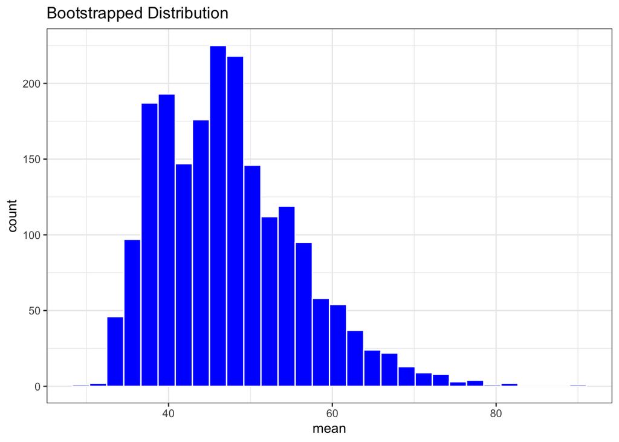

```r
get_mean <- function(df){
  mean <- df %>%
    pull(new_deaths) %>%
    mean()
  return(mean)
}

create_bootstrap <- function(df){
  boot <- df %>%
    slice_sample(prop = 1, replace = TRUE)
  return(boot)
}

mean_bootstrap <- function(df){
  boot_m <- create_bootstrap(df) %>%
    get_mean()
  return(boot_m)
}

boot_res <- map_dbl(1:2000, function(x) mean_bootstrap(ny_covid21))

res_tibble <- tibble(run = 1:2000, mean = boot_res)

ggplot(data = res_tibble) +
  geom_histogram(aes(x = mean), color = "white", fill = "blue") +
  theme_bw() +
  labs(title = "Bootstrapped Distribution")
```

```r
boot_ci <- res_tibble %>%
  summarize(lower_ci = quantile(mean, 0.025),
         upper_ci = quantile(mean, 0.975))
```

### e)

Compare the confidence intervals in parts (c) and (d). Are they the same? Different? If they are different, which confidence interval is wider, and by how much?

### f)

Select five states of your choosing and create a line graph showing newly reported COVID-19 daily deaths from 01/01/21 onward, with states differentiated by color. Make at least *(3)* improvements to a basic ggplot (think about labeling, custom colors, themes, etc)

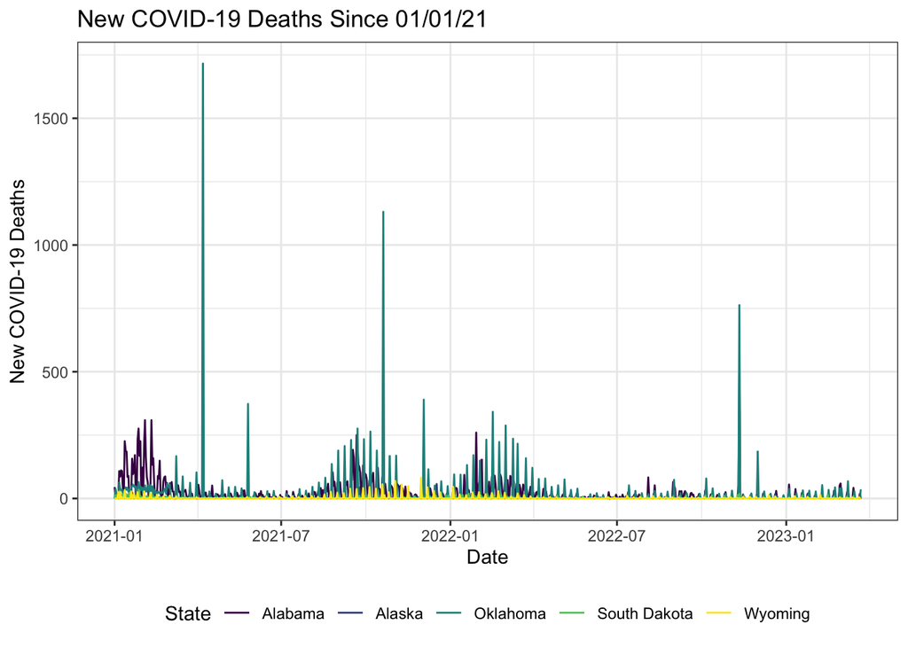

```r
covid_graphs <- covid_raw %>%
  filter(str_detect(state, "Alabama|Alaska|South Dakota|Oklahoma|Wyoming")) %>%
  arrange(state, date) %>%
  mutate(new_deaths = deaths - lag(deaths)) %>%
  filter(date >= "2021-01-01")

ggplot(data = covid_graphs) +
  geom_line(aes(x = date, y = new_deaths, color = state)) +
  theme_bw() +
  labs(x = "Date", y = "New COVID-19 Deaths",
       title = "New COVID-19 Deaths Since 01/01/21",
       color = "State") +
  scale_color_manual(values = viridis::viridis(5)) +
  theme(legend.position = "bottom")
```

## Question 2

You have received two raw datasets containing the exposure status and demographics for a small pilot study. The data is currently a bit messy, so your first goal is to clean it and produce a small table 1 describing the demographics between two groups.

### a)

Load the `pilot_exposure.csv` and `pilot_demo.csv` files into your environment. Figure out how to join them together so only participants with exposure information are included in the final file.

```r
pilot_exp <- read_csv("data/pilot_exposure.csv")

exp_cleaned <- pilot_exp %>%
  mutate(id_number = str_remove(id_number, "STUDY-114:ID:") %>% as.numeric())

pilot_demo <- read_csv("data/pilot_demo.csv")

pilot_joined <- exp_cleaned %>%
  left_join(pilot_demo, by = "id_number")
```

### b)

You have been asked to clean up the demographic data and code variables into the following categories:

**Gender** “Male” and “Female” (Current coding has 0 = Male and 1 = Female)

**Ethnicity** “Hispanic” and “Non-Hispanic”

**Race** “White”, “Black”, “Unknown”

**Marital Status** “Single/Separated/Divorced” and “Married”

Use string manipulation functions to create these variables and categories.

```r
pilot_cleaned <- pilot_joined %>%
  mutate(gender_cl = case_when(gender == 0 ~ "Male",
                              gender == 1 ~ "Female"),
         ethnicity_cl = case_when(str_detect(eth, "N-Hispanic") ~ "Non-Hispanic",
                                   str_detect(eth, "isp") ~ "Hispanic"),
         race_cl = case_when(str_detect(race, "lack|LACK") ~ "Black",
                             str_detect(race, "wh|WH|Wh") ~ "White",
                             str_detect(race, "unk|Unk|not known") ~ "Unknown"),
         marital_cl = case_when(str_detect(marital, "SINGLE|ingle|ivorce|eparat") ~ "Single/Separated/Divorced",
                                str_detect(marital, "arred|aried") ~ "Married"))
```

### c)

Now that the variables have been cleaned, create a descriptive table of the entire sample using `tbl_summary()`.

Make sure:

1. You include your cleaned gender, race, ethnicity, and marital status variables as well as age and education in years in your table.
2. Categorical variables are summarized using n(%) and continuous variables are summarized using mean(sd).
3. Each variable is labeled, not left with just a raw variable name.

```r
pilot_cleaned %>%
  select(gender_cl, ethnicity_cl, race_cl, marital_cl, age, edu_yrs) %>%
  tbl_summary(label = list(gender_cl ~ "Gender",
                           ethnicity_cl ~ "Ethnicity",
                           race_cl ~ "Race",
                           marital_cl ~ "Marital Status",
                           age ~ "Age",
                           edu_yrs ~ "Education (yrs)"),
              statistic = all_continuous() ~ "{mean} ({sd})",
              type = edu_yrs ~ "continuous")
```

| **Characteristic** | **N = 18**<sup>1</sup> |
| --- | --- |
| Gender |  |
| Female | 4 (22%) |
| Male | 14 (78%) |
| Ethnicity |  |
| Hispanic | 15 (83%) |
| Non-Hispanic | 3 (17%) |
| Race |  |
| Black | 5 (28%) |
| Unknown | 7 (39%) |
| White | 6 (33%) |
| Marital Status |  |
| Married | 6 (33%) |
| Single/Separated/Divorced | 12 (67%) |
| Age | 40 (11) |
| Education (yrs) | 13.9 (2.9) |

<sup>1</sup> n (%); Mean (SD)

### d)

Now create a table with the same variables split by exposure group status. Include a column that shows the p-value for tests for differences between exposure groups for all variables. Make sure that the tests used for continuous variables are two-sample t-tests assuming equal variances.

```r
pilot_cleaned %>%
  select(gender_cl, ethnicity_cl, race_cl, marital_cl, age, edu_yrs, exposure_status) %>%
  tbl_summary(by = "exposure_status",
    label = list(gender_cl ~ "Gender",
                           ethnicity_cl ~ "Ethnicity",
                           race_cl ~ "Race",
                           marital_cl ~ "Marital Status",
                           age ~ "Age",
                           edu_yrs ~ "Education (yrs)"),
              statistic = all_continuous() ~ "{mean} ({sd})",
              type = edu_yrs ~ "continuous") %>%
  add_p(test = all_continuous() ~ "t.test",
        test.args = all_tests("t.test") ~ list(var.equal = TRUE))
```

| **Characteristic** | **Exposed**, N = 3<sup>1</sup> | **Unexposed**, N = 15<sup>1</sup> | **p-value**<sup>2</sup> |
| --- | --- | --- | --- |
| Gender |  |  | >0.9 |
| Female | 0 (0%) | 4 (27%) |  |
| Male | 3 (100%) | 11 (73%) |  |
| Ethnicity |  |  | 0.4 |
| Hispanic | 2 (67%) | 13 (87%) |  |
| Non-Hispanic | 1 (33%) | 2 (13%) |  |
| Race |  |  | 0.6 |
| Black | 0 (0%) | 5 (33%) |  |
| Unknown | 1 (33%) | 6 (40%) |  |
| White | 2 (67%) | 4 (27%) |  |
| Marital Status |  |  | 0.2 |
| Married | 2 (67%) | 4 (27%) |  |
| Single/Separated/Divorced | 1 (33%) | 11 (73%) |  |
| Age | 46 (14) | 39 (11) | 0.4 |
| Education (yrs) | 15.3 (4.2) | 13.6 (2.7) | 0.4 |

<sup>1</sup> n (%); Mean (SD)  
<sup>2</sup> Fisher's exact test; Two Sample t-test

## Question 3

Last week you explored associations between skeletal/girth measures and obesity status. For this problem, we’ll be returning to those models using the same `body_measures.csv` dataset.

### a)

**If you did not complete Q3 in HW08:** you must fit logistic regression models to explore the relationship between obesity status and three skeletal/girth measurements of your choice. This means you need to calculate BMI and create the 0/1 obesity outcome based on a BMI >= 30. You should result in 3 models, each one exploring the relationship between a measurement and obesity status. Your models can include adjustment for other variables if you wish.

**If you completed Q3 in HW08:** you can cut/paste your code from that assignment to set up the data and re-fit your three obesity status models.

```r
bm_raw <- read_csv("data/body_measures.csv")

bm_bmi <- bm_raw %>%
  mutate(bmi = round(weight/(height/100)^2,1)) %>%
  mutate(obese = if_else(bmi >= 30, 1, 0))

wristg_obese_mod <- glm(obese ~ wrist_girth + age + gender, family = "binomial",
                       data = bm_bmi)

shoulderg_obese_mod <- glm(obese ~ shoulder_girth + age + gender, family = "binomial",
                       data = bm_bmi)

elbow_obese_mod <- glm(obese ~ elbow_diameter + age + gender, family = "binomial",
                       data = bm_bmi)
```

### b)

One of your collaborators is very enthusiastic about reporting the BIC for each logistic regression model. This is a measure of overall model fit, with lower BIC indicating better fit. Use the `broom` package to access the BIC measure for each of your 3 logistic regression models and report them in a sentence using in-line coding.

```r
wristmod_bic <- wristg_obese_mod %>%
  glance() %>%
  pull(BIC)

shouldermod_bic <- shoulderg_obese_mod %>%
  glance() %>%
  pull(BIC)

elbowmod_bic <- elbow_obese_mod %>%
  glance() %>%
  pull(BIC)
```

Answer:

The BIC for the wrist girth model is 169.087; the BIC for the shoulder girth model is 143.194; and the BIC for the elbow diameter model is 173.638.

### c)

Excited by the prospect of comparing models based on BIC, your colleague asks you to calculate the 95% CI for the BIC of each model. Unfortunately, you can’t find a formula anywhere online to do this – so you decide to bootstrap them using 1000 replicates. Show the simulated bootstrap distribution of BIC values for each model, and report the empirical 95% confidence interval for each model.

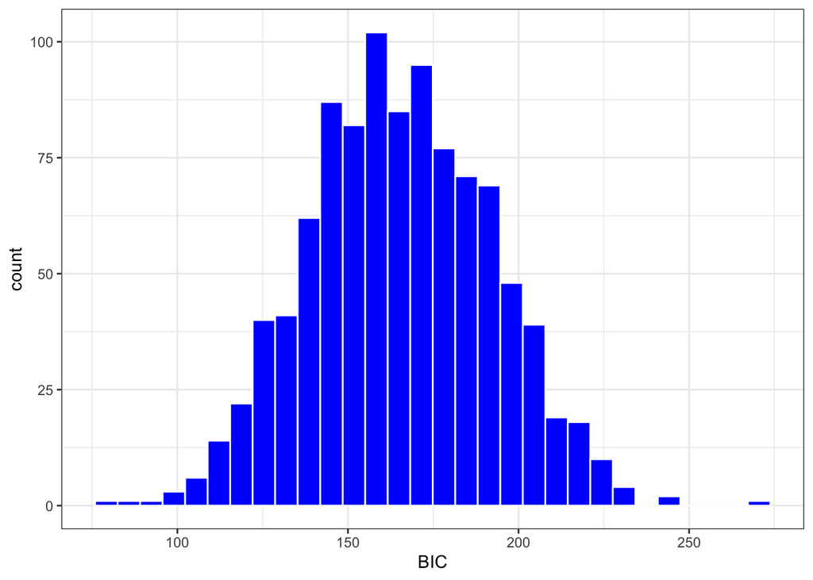

```r
get_BIC <- function(df, formula){
  f <- as.formula(formula)
  mod <- glm(f, family = "binomial",
                       data = df)
  BIC <- mod %>%
    glance() %>%
    pull(BIC)
  return(BIC)
}

get_bootstrap <- function(df){
  boot <- df %>%
    slice_sample(prop = 1, replace = TRUE)
  return(boot)
}

get_boot_BIC <- function(df, formula){
  boot_BIC <- get_bootstrap(df) %>%
    get_BIC(formula)
  return(boot_BIC)
}

wrist_boot_bic <- map_dbl(1:1000, function(x) get_boot_BIC(bm_bmi, "obese ~ wrist_girth + age + gender"))

shoulder_boot_bic <- map_dbl(1:1000, function(x) get_boot_BIC(bm_bmi, "obese ~ shoulder_girth + age + gender"))

elbow_boot_bic <- map_dbl(1:1000, function(x) get_boot_BIC(bm_bmi, "obese ~ elbow_diameter + age + gender"))

boot_tibble <- tibble(wrist = wrist_boot_bic, shoulder = shoulder_boot_bic,
                      elbow = elbow_boot_bic)

ggplot(boot_tibble) +
  geom_histogram(aes(x = wrist), color = "white", fill = "blue") +
  theme_bw() +
  labs(x = "BIC")
```

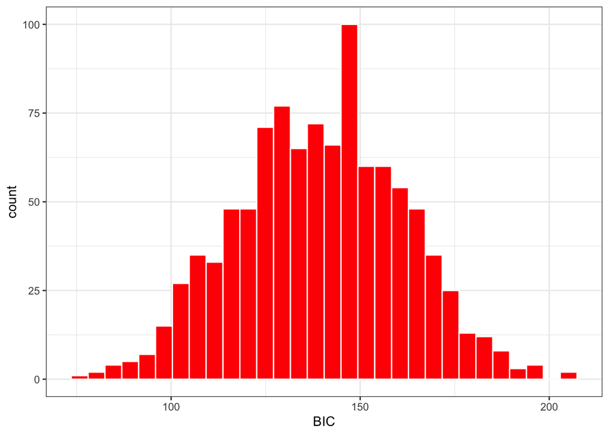

```r
ggplot(boot_tibble) +
  geom_histogram(aes(x = shoulder), color = "white", fill = "red") +
  theme_bw() +
  labs(x = "BIC")
```

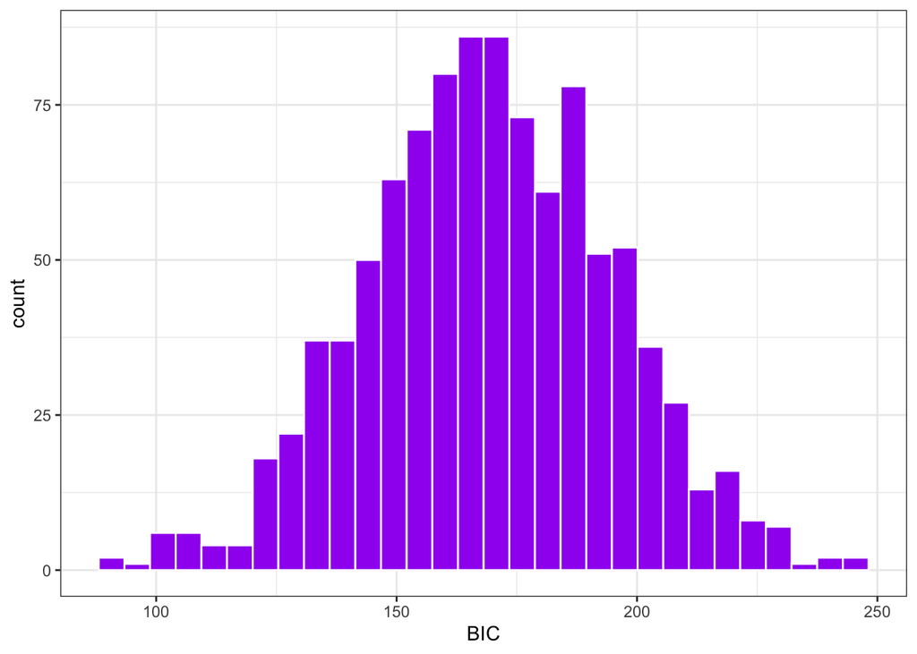

```r
ggplot(boot_tibble) +
  geom_histogram(aes(x = elbow), color = "white", fill = "purple") +
  theme_bw() +
  labs(x = "BIC")
```

```r
longer_boot <- boot_tibble %>%
  pivot_longer(cols = any_of(c("wrist", "elbow", "shoulder")),
               names_to = "measure",
               values_to = "boot_mean")

booted_cis <- longer_boot %>%
  group_by(measure) %>%
  summarize(lower_ci = quantile(boot_mean, 0.025),
            upper_ci = quantile(boot_mean, 0.975),
            pretty_ci = str_c("(", round(lower_ci,2), ", ",
                                 round(upper_ci, 2), ")"))
```

### d)

Next up, you’ve been asked to produce a combined plot of the OR’s and 95% CI for your measurements of interest and the BIC and bootstrapped 95% CI for each model in a “forest plot” type layout.

To do this: (1) Create one plot of the OR’s and 95% CI for your three measurements association with obesity. (2) Create a second plot of the BIC’s and 95% CI for your three models. (3) Combine the two plots using `patchwork`.

Make sure that: (1) Your two sub-plots have consistent themes. (2) Your axes are properly labeled, and the variables and models have clear descriptions (not raw variable names). (3) You indicate somehow that the 95% CI for BIC has been bootstrapped.

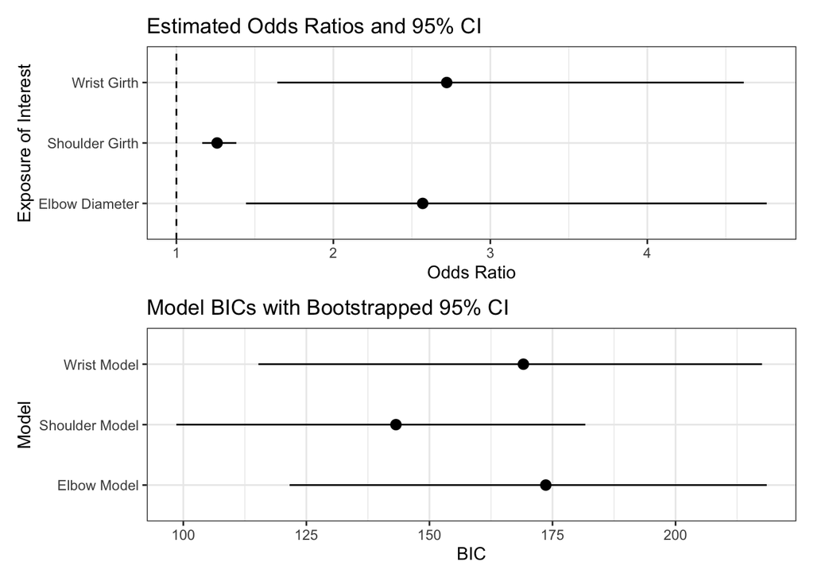

```r
or_data <- bind_rows(tidy(wristg_obese_mod, exponentiate = TRUE, conf.int = TRUE),
                     tidy(shoulderg_obese_mod, exponentiate = TRUE, conf.int = TRUE),
                     tidy(elbow_obese_mod, exponentiate = TRUE, conf.int = TRUE)) %>%
  filter(str_detect(term, "elbow|shoulder|wrist")) %>%
  mutate(term = str_replace(term, "_", " ") %>% str_to_title())

or_graph <- ggplot(data = or_data) +
  geom_pointrange(aes(y = term, x = estimate, xmin = conf.low, xmax = conf.high)) +
  theme_bw() +
  geom_vline(aes(xintercept = 1), linetype = "dashed") +
  labs(x = "Odds Ratio", y = "Exposure of Interest", title = "Estimated Odds Ratios and 95% CI")

bic_lookup <- tibble(measure = c("wrist", "shoulder", "elbow"), bic = c(wristmod_bic, shouldermod_bic,
                                                                        elbowmod_bic))


bic_graph_dat <- booted_cis %>%
  left_join(bic_lookup, by = "measure") %>%
  mutate(measure = str_c(str_to_title(measure), " Model"))

bic_graph <- ggplot(bic_graph_dat) +
  geom_pointrange(aes(y = measure, x = bic, xmin = lower_ci, xmax = upper_ci)) +
  theme_bw() +
  labs(x = "BIC", y = "Model", title = "Model BICs with Bootstrapped 95% CI")


or_graph / bic_graph
```

### e)

Based on the 95% CI’s in your graph in (e), would you say that the BIC for your three models differ? Why or why not?

Answer:

Although it isn’t a definitive hypothesis test, it looks like the 95% confidence intervals for all three of these model BIC’s overlap, so I don’t see evidence of a significant difference in fit between them.